# Who Wants to Be a PoliMillionaire? — NLP 2025/26 Group Assignment

## Group members

- Jiaxin Yang — jiaxin.yang@mail.polimi.it
- Runjie (Simone) Dai — runjie.dai@mail.polimi.it

## Video

- Presentation video (≤5 min): https://youtu.be/Ub6XI_UnmH4?is=sGyjGIwOUgvoBZf9

## Statement on coding assistants

We used a coding assistant (Claude Code) to help write, refactor and document parts of the implementation. The system design, the experiments, and the prompt / RAG / routing strategies and all analysis are our own; the assignment was **not** handed to an LLM to complete.

## What this notebook is

A self-explanatory consolidation of our whole pipeline and study, in narrative order:

| § | Section | Rubric question it answers |
| --- | --- | --- |
| 1 | Setup | — (clone branch `science`, install, paths, game client) |
| 2 | Baseline single-model QA | 30s feasibility · per-topic strengths · overconfidence · failure modes |
| 3 | Prompt engineering | best prompt (zero / few / CoT) · prompt sensitivity |
| 4 | Adaptive prompt routing | adaptive prompting · *when does reasoning help vs hurt* · failure taxonomy |
| 5 | Tools + ensemble voting | calculator lift · self-consistency / ensemble reliability (agentic AI) |
| 6 | RAG (live web, raw content only) | RAG lift · RAG-vs-no-RAG ablation |
| 7 | Model comparison | model A/B · size vs quality |
| 8 | Live play — the real game | the leaderboard result (the actual test) |
| 9 | Conclusions | every investigation question → our finding |

> **How to read / reproduce.** Outputs are **preserved** from each experiment's own Colab run — the offline studies (§2–§7) are not meant to be re-run end-to-end in one pass (each loads the 7B model with its own config). To reproduce a single section: run **§1 Setup**, then that section's cells. The **live leaderboard run (§8)** is the only section we refresh for the final submission.

> Rules respected throughout: open-weight model run **locally** on Colab (`Qwen/Qwen2.5-7B-Instruct`, 4-bit), ≤30 s/question, and RAG uses **raw retrieved content only** (never generated answers). Code comments are in Yoda style (an assignment requirement).

# §1 · Setup — clone (branch `science`), install deps, paths, game client

One canonical setup for the whole notebook. Pulls the code from GitHub (branch **`science`**), installs the inference stack + headless Chromium (for the live-News body fetch), and puts `src` + the provided `millionaire_client` on the path. Run this once.

```python
# Auto-reload edited src modules on every cell run -- so after a `git pull` the newest code lands without a
# manual importlib.reload or a restart. (Re-run the cell that USES the code, e.g. code-wire.)
# Colab's IPython ships an autoreload that does `from imp import reload`, and `imp` is GONE in Python 3.12 --
# so a tiny `imp` shim (reload only) we install first, then load the extension. BEST-EFFORT: any failure
# caught, so the cell never stalls (fall back: after a src pull, Runtime > Restart to pick changes up).
try:
    import sys as _sys, types as _types, importlib as _importlib
    if 'imp' not in _sys.modules:
        _imp = _types.ModuleType('imp')
        _imp.reload = _importlib.reload          # the one thing the old autoreload.py wants from `imp`.
        _sys.modules['imp'] = _imp
    _ip = get_ipython()
    _ip.run_line_magic('load_ext', 'autoreload')
    _ip.run_line_magic('autoreload', '2')
    print('autoreload: ON (src edits hot-reload on cell re-run)')
except Exception as _e:
    print(f'autoreload OFF ({type(_e).__name__}: {_e}) -- after a src pull, Runtime > Restart to pick changes up.')

import os, sys

REPO_URL = 'https://github.com/SleepyEveryD/NLP.git'
REPO_ROOT = '/content/NLP'
BRANCH = 'science'
if not os.path.exists(REPO_ROOT):
  !git clone -b {BRANCH} {REPO_URL} {REPO_ROOT}
else:
  # Already cloned -> HARD-SYNC to the latest pushed branch (fetch + force-reset to origin/{BRANCH}).
  # Tracked files are overwritten to match remote; UNTRACKED run outputs are KEPT (experiments/runs/* is
  # gitignored). NOTE: `git pull` updates the FILES on disk -- it does NOT refresh THIS notebook's cells.
  !cd {REPO_ROOT} && git fetch -q origin && git checkout -q -f -B {BRANCH} origin/{BRANCH}

!cd {REPO_ROOT} && echo "on branch:" $(git rev-parse --abbrev-ref HEAD) "@" $(git --no-pager log -1 --oneline)

SRC = os.path.join(REPO_ROOT, 'src')
API_CLIENT = os.path.join(REPO_ROOT, 'NLP_assignment_api_client')
for p in (SRC, API_CLIENT):
  if p not in sys.path:
    sys.path.insert(0, p)
os.chdir(REPO_ROOT)
print('Repo root:', REPO_ROOT)

from millionaire_client import MillionaireClient
print('millionaire_client, imported it is.')
```

```
The autoreload extension is already loaded. To reload it, use:
  %reload_ext autoreload
autoreload: ON (src edits hot-reload on cell re-run)
on branch: science @ 9713b3e test science
Repo root: /content/NLP
millionaire_client, imported it is.
```

```python
# The inference stack + the client's `requests`, install we do (light it stays). `-U` kept (Colab a stale
# bitsandbytes preinstalls); pandas/requests PINNED to Colab's versions; matplotlib NOT upgraded (bare `-U` breaks google-colab/cudf, and upgrading matplotlib mid-session breaks the already-imported backend_bases). Colab ships matplotlib; requirements.txt covers local.
!pip install -q -U 'transformers>=4.45.0' 'accelerate>=0.34.0' 'bitsandbytes>=0.46.1' sentencepiece einops pyyaml 'pandas==2.2.2' 'requests==2.32.4'
print('Installed, the dependencies are.')
```

```
Installed, the dependencies are.
```

```python
# Headless Chromium -- the live-NEWS body fetch it powers (configs/live.yaml: news_body_mode "browser").
# The relevance gate now ROUTES off-topic Guardian results here, so the browser matters MORE for News.
# Skip this only if you set retrieval.news_body_mode: "off".
!pip install -q playwright
!playwright install chromium
!playwright install-deps

# ARMED? Probe inside a WORKER THREAD (its own event loop) -- EXACTLY how the real fetcher runs
# (src/retrieval/browser_fetch.py). A bare sync_playwright() in the cell would hit Jupyter/Colab's
# asyncio loop and FALSELY report "not ready" ("Sync API inside asyncio loop"), even though live-News
# body fetch works fine. NOT ready -> News falls back to HEADLINES only (crash-safe).
import threading
_probe = {}
def _probe_browser():
    try:
        from playwright.sync_api import sync_playwright
        with sync_playwright() as _p:
            _b = _p.chromium.launch(headless=True); _b.close()
        _probe['ok'] = True
    except Exception as _e:
        _probe['err'] = f'{type(_e).__name__}: {_e}'
_t = threading.Thread(target=_probe_browser); _t.start(); _t.join(timeout=120)
if _probe.get('ok'):
    print('headless Chromium: READY -- live-News body fetch armed.')
else:
    print(f"headless Chromium NOT ready ({_probe.get('err', 'launch timed out')})")
    print('   -> News will use HEADLINES only. Re-run this cell, or set retrieval.news_body_mode: "off".')
```

[output not shown]

[output cut: 712 more lines]

[output not shown]

# §2 · Baseline single-model QA *(Phase 1 — the MVP)*

The first answering pipeline: load Qwen2.5-7B 4-bit once, wire the `QAPipeline`, and benchmark zero-shot over the dev set. This section establishes **30 s feasibility**, **per-topic strengths**, **overconfidence**, and the dominant **failure modes** — the questions the rubric asks first.

## 2 · Load the run config

Into every run logged it is (D-007) — reproducible, the science stays.

```python
from config import RunConfig

# The base config, from YAML we load.
config = RunConfig.from_yaml(os.path.join(REPO_ROOT, 'configs', 'base.yaml'))
print('run_id:', config.run_id)
print('model:', config.model.name, '|', config.model.quantization, '|', config.model.dtype)
print('latency budget:', config.latency_budget_s, 's')
print('prompt strategy:', config.prompt_strategy)
```

```
run_id: baseline
model: Qwen/Qwen2.5-7B-Instruct | 4bit | bfloat16
latency budget: 30.0 s
prompt strategy: zero_shot_v1
```

## 3 · Load + warm up the model

```python
import time
#TransformersEngine is used to handle transformers
from inference.engine import TransformersEngine

t0 = time.perf_counter()
engine = TransformersEngine(
    model_name=config.model.name,
    quantization=config.model.quantization,
    dtype=config.model.dtype,
)
load_s = time.perf_counter() - t0
print(f'Model loaded in {load_s:.1f}s')

# Warm up -- the first-call kernels, compiled before any timed question they are.
t0 = time.perf_counter()
engine.warmup()
warm_s = time.perf_counter() - t0
print(f'Warmup in {warm_s:.1f}s')

# A smoke generation -- the answering path works, confirm we do.
t0 = time.perf_counter()
out = engine.generate('Reply with the single letter B and nothing else.', max_new_tokens=5)
gen_s = time.perf_counter() - t0
print(f'Smoke generate in {gen_s:.2f}s -> {out!r}')
print(f'tokens_in={engine.last_tokens_in}, tokens_out={engine.last_tokens_out}')
```

```
tokenizer_config.json: 0.00B [00:00, ?B/s]
```

```
vocab.json: 0.00B [00:00, ?B/s]
```

```
merges.txt: 0.00B [00:00, ?B/s]
```

```
tokenizer.json: 0.00B [00:00, ?B/s]
```

```
`torch_dtype` is deprecated! Use `dtype` instead!
```

```
model.safetensors.index.json: 0.00B [00:00, ?B/s]
```

```
Downloading (incomplete total...): 0.00B [00:00, ?B/s]
```

```
The following generation flags are not valid and may be ignored: ['temperature', 'top_p', 'top_k']. Set `TRANSFORMERS_VERBOSITY=info` for more details.
```

```
Model loaded in 252.5s
Warmup in 1.5s
Smoke generate in 0.64s -> 'B'
tokens_in=39, tokens_out=2
```

## 4 · Wire the pipeline + a single-question demo

Dependency injection (D-006): engine, classifier and prompt builder, injected they are. RAG and tools, off for the baseline they stay (Phase 4 and Phase 3 turn them on).

```python
from classify.classifier import QuestionClassifier
from prompting.builder import PromptBuilder
from agent.pipeline import QAPipeline
from evaluation.dataset import load_questions

# The collaborators, injected into the pipeline they are (D-006).
classifier = QuestionClassifier()
prompt_builder = PromptBuilder(strategy=config.prompt_strategy)
pipeline = QAPipeline(
    engine=engine,
    prompt_builder=prompt_builder,
    classifier=classifier,
    retriever=None,   # Off for the baseline -- Phase 4 turns it on.
    tools=None,       # Off for the baseline -- Phase 3 turns it on.
    latency_budget_s=config.latency_budget_s,
)

# The dev question set, from disk loaded it is.
questions = load_questions(os.path.join(REPO_ROOT, 'data', 'dev_questions.jsonl'))
print(f'Loaded {len(questions)} dev questions.')

# One question, end to end through the pipeline we run -- the moving parts, inspect them we do.
demo_q = questions[0]
enriched = classifier.classify(demo_q)
print('--- The built prompt ---')
print(prompt_builder.build(enriched))
print()
pred = pipeline.answer(demo_q)
print('--- The prediction ---')
print('raw_output:', repr(pred.raw_output))
print('parsed answer:', pred.answer, '| gold:', demo_q.gold, '| confidence:', pred.confidence)
print('latency_s:', round(pred.latency_s, 2), '| tokens_out:', pred.tokens_out)
```

```
Loaded 23 dev questions.
--- The built prompt ---
Question: Which planet in our solar system has the most moons?
A) Jupiter
B) Saturn
C) Uranus
D) Neptune
Reply with ONLY the letter of the correct option (A, B, C, or D). No explanation, no punctuation -- the letter alone.

--- The prediction ---
raw_output: 'A'
parsed answer: A | gold: B | confidence: 1.0
latency_s: 0.97 | tokens_out: 2
```

### 🔬 Core implementation: the seven-stage `QAPipeline.answer()` orchestration

Above we `import`ed `QAPipeline`. Its full logic lives in `src/agent/pipeline.py`; here we show the **core orchestration** directly, so the whole system is easy to follow: one question in -> one `Prediction` out. Seven stages run in order, every collaborator is dependency-injected (dormant when `None`), and the whole thing is crash-safe (in live mode we must ALWAYS be able to submit an answer).

```
def answer(self, question: Question) -> Prediction:
    guard = LatencyGuard(self.latency_budget_s)   # 30s budget, timed end-to-end
    try:
        # 1) classify -- tag the question with topic / type / language
        if self.classifier:
            question = self.classifier.classify(question)

        # 2) solver short-circuit (Maths only) -- a deterministic hit answers directly, skips the LLM
        if self.solver is not None:
            sol = self.solver(question)
            if sol is not None:
                letter, evidence = sol
                return Prediction(qid=question.qid, answer=letter, confidence=1.0,
                                  tool_used="math_solver", ...)

        # 3) retrieve -- only if a retriever exists AND the classifier says evidence is needed
        #    (RAG, RAW documents, never an LLM answer)
        if self.retriever and (not self.classifier or self.classifier.needs_retrieval(question)):
            docs = self.retriever.retrieve(question)
            retrieval_used = True

        # 4) prompt -- build the user-turn from the question + optional evidence
        prompt = self.prompt_builder.build(question, docs)

        # 5) generate -- n=1 single greedy pass; n>1 runs self-consistency (vote over N sampled CoT chains)
        if self.self_consistency_n > 1:
            ans, conf, raw = self._self_consistency_answer(prompt, question, guard)
        else:
            raw = self._gen(prompt)

        # 6) tool -- the calculator as a "verifier": only on arithmetic Qs, no retrieval, not self-consistency
        if (self.self_consistency_n <= 1 and self.tools and self.classifier
                and not retrieval_used and self.classifier.needs_calculator(question)):
            tool_raw, used = self._run_calculator_tool(question, guard)
            if tool_raw is not None:
                raw, tool_used = tool_raw, used

        # 7) parse -- robustly turn the model text into (answer, confidence)
        if self.self_consistency_n <= 1:
            ans, conf = QAPipeline.parse_answer(raw, question)

    except Exception as e:
        # any crash -> fall back to the first option; a live game never goes silent
        return Prediction(..., answer=fallback_ans, confidence=0.0, error=str(e))

    return Prediction(qid=question.qid, answer=ans, confidence=conf, ...)
```

**Parser robustness**: `parse_answer()` extracts the option letter from the model's free text with a 7-tier pattern ladder -- `Answer: B` -> `(C)` -> `Option D` -> `B)` -> `B Rome` (echoes the option text) -> a whole-line single letter -> any isolated letter, confidence decreasing down the ladder; if nothing matches it falls back to the first option (live must have an answer). Full implementation in `src/agent/pipeline.py`.

## 5 · Run the baseline benchmark

Over all dev questions the pipeline runs; one `EvalRecord` per question, to JSONL it is logged (D-007). Crash-safe it is — each line flushed immediately, so a Colab disconnect nothing it loses.

```python
from evaluation.runner import BenchmarkRunner

# Into the repo the run logs we write.
runner = BenchmarkRunner(
    pipeline=pipeline,
    config=config,
    log_root=os.path.join(REPO_ROOT, 'experiments', 'runs'),
)
run_path = runner.run(questions)
print('Run written to:', run_path)
```

```
[1/23] qid=dev-001 ...
[2/23] qid=dev-002 ...
[3/23] qid=dev-003 ...
[4/23] qid=dev-004 ...
[5/23] qid=dev-005 ...
[6/23] qid=dev-006 ...
[7/23] qid=dev-007 ...
[8/23] qid=dev-008 ...
[9/23] qid=dev-009 ...
[10/23] qid=dev-010 ...
[11/23] qid=dev-011 ...
[12/23] qid=dev-012 ...
[13/23] qid=dev-013 ...
[14/23] qid=dev-014 ...
[15/23] qid=dev-015 ...
[16/23] qid=dev-016 ...
[17/23] qid=dev-017 ...
[18/23] qid=dev-018 ...
[19/23] qid=dev-019 ...
[20/23] qid=dev-020 ...
[21/23] qid=dev-021 ...
[22/23] qid=dev-022 ...
[23/23] qid=dev-023 ...
Run written to: /content/NLP/experiments/runs/baseline
```

## 6 · Results — accuracy + latency

From the JSONL log all of it derives — re-analyse without re-running the model, we can.

```python
from evaluation.metrics import load_runs, accuracy_by, latency_summary

# The logged run, back into a DataFrame we read.
df = load_runs([run_path])

# Overall accuracy, the headline number it is.
known = df[df['correct'].notna()]
overall = known['correct'].astype(float).mean()
print(f'Overall accuracy: {overall:.1%}  (n={len(known)})')
print()
print('--- Accuracy by topic ---')
print(accuracy_by(df, 'topic').to_string(index=False))
print()
print('--- Accuracy by level ---')
print(accuracy_by(df, 'level').to_string(index=False))
print()
print('--- Latency summary (seconds) ---')
for k, v in latency_summary(df).items():
    print(f'{k}: {v}')
```

```
Overall accuracy: 87.0%  (n=23)

--- Accuracy by topic ---
                       topic  accuracy  n
Ancient History and Politics      1.00  4
               Entertainment      1.00  4
                       Maths      0.50  4
                        News      1.00  4
   Philosophy and Psychology      1.00  3
          Science and Nature      0.75  4

--- Accuracy by level ---
 level  accuracy  n
     1  1.000000  1
     2  1.000000  4
     3  0.800000  5
     4  1.000000  3
     5  0.800000  5
     6  0.666667  3
     7  1.000000  1
     8  1.000000  1

--- Latency summary (seconds) ---
median_s: 0.9095702419999725
p95_s: 1.0133455697998897
max_s: 1.050432285999932
mean_s: 0.9193495519130505
over_budget: 0
budget_violation_rate: 0.0
```

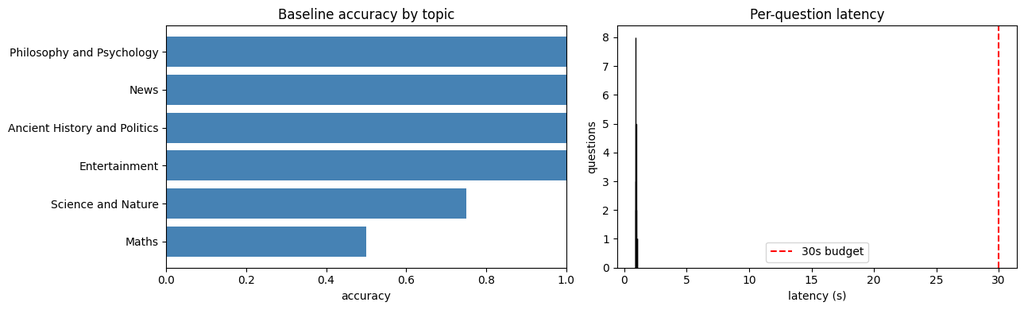

```python
import matplotlib.pyplot as plt

# Accuracy by topic, a bar chart it becomes -- per-topic strengths, the rubric asks for them.
topic_acc = accuracy_by(df, 'topic').sort_values('accuracy')
fig, ax = plt.subplots(1, 2, figsize=(13, 4))
ax[0].barh(topic_acc['topic'], topic_acc['accuracy'], color='steelblue')
ax[0].set_xlim(0, 1)
ax[0].set_xlabel('accuracy')
ax[0].set_title('Baseline accuracy by topic')

# Latency per question, a histogram it forms -- the 30s wall, a red line marks it.
ax[1].hist(df['latency_s'].dropna(), bins=12, color='darkorange', edgecolor='black')
ax[1].axvline(30.0, color='red', linestyle='--', label='30s budget')
ax[1].set_xlabel('latency (s)')
ax[1].set_ylabel('questions')
ax[1].set_title('Per-question latency')
ax[1].legend()
plt.tight_layout()
plt.show()
```

```python
miss = df[(df['correct'] == False)][['qid', 'topic', 'question_text', 'predicted_answer', 'gold_answer', 'confidence',
  'raw_output']]
import pandas as pd
pd.set_option('display.max_colwidth', None)
print(miss.to_string(index=False))
```

```
    qid              topic                                        question_text predicted_answer gold_answer  confidence raw_output
dev-001 Science and Nature Which planet in our solar system has the most moons?                A           B         1.0          A
dev-005              Maths                         What is 17 multiplied by 13?                D           B         1.0          D
dev-008              Maths                        What is 2 to the power of 10?                A           C         1.0          A
```

## 30s feasibility

The baseline pipeline runs comfortably under the 30s limit on a T4 GPU.

Latency summary:

- Median latency: ~0.91s
- p95 latency: ~1.01s
- Max latency: ~1.05s
- Budget violation rate: 0%

This leaves a very large safety margin under the 30-second game constraint.

## Per-topic strengths

Strongest topics at baseline:

- Ancient History and Politics — 100%
- Entertainment — 100%
- News — 100%
- Philosophy and Psychology — 100%

Weakest topics:

- Maths — 50% accuracy (worst performing topic)
- Science and Nature — 75% accuracy

This suggests the zero-shot prompting setup performs well on factual recall and general knowledge, but struggles more with reasoning-heavy or calculation-based questions.

## Overconfidence

Yes — there is evidence of overconfidence.

Example:

- The model answered the moons question incorrectly (`A` instead of the correct answer `B`)
- Reported confidence was still `1.0`

This indicates the baseline system is poorly calibrated: it can produce highly confident but incorrect answers.

## Failure modes

The observed failures appear to be mainly real knowledge or reasoning gaps rather than parser failures.

Evidence:

- Raw outputs were generally clean single-letter responses such as `'A'`
- The parser extracted answers successfully
- No obvious formatting or chatter issues appeared in the baseline run

The main failure causes are likely:

- Weak mathematical reasoning
- Incorrect factual recall
- Limited reasoning ability under zero-shot prompting

No major parser breakdowns were observed.

## Next steps

Next, we should test:

- `few_shot_v1`
- `cot_v1` (chain-of-thought prompting)

These prompting strategies may improve reasoning accuracy, especially for Maths and Science questions, while still remaining comfortably within the 30-second latency budget.

# §3 · Prompt engineering *(Phase 2)*

Three prompt strategies head-to-head on the dev set — **zero-shot**, **few-shot**, **chain-of-thought** — plus `cot_v2`, a CoT variant driven by two real failure cases (option-matching slips on Maths). Which prompt is truly best, and how sensitive is the model to phrasing?

# 02 · Prompt engineering (Phase 2)

**Who Wants to Be a PoliMillionaire?** — three prompt strategies, head to head this section runs.

The baseline (§2) scored **87%**, with the misses concentrated in **Maths** (arithmetic errors) and one **Science** knowledge-cutoff trap. The central question here:

> Does **chain-of-thought** (think step by step) rescue the arithmetic on its own — or is a deterministic **calculator tool** (Phase 3) actually required?

Same engine, same dev set, same pipeline seam — **only the prompt strategy changes**: `zero_shot_v1` · `few_shot_v1` · `cot_v1`. The model, loaded ONCE it is; three benchmarks then run.

> **GPU needed.** Runtime ▸ Change runtime type ▸ T4 GPU, select you must.

## 2 · Load the model once + the dev set

```python
import time
from config import RunConfig
from inference.engine import TransformersEngine
from classify.classifier import QuestionClassifier
from evaluation.dataset import load_questions

config = RunConfig.from_yaml(os.path.join(REPO_ROOT, 'configs', 'base.yaml'))

# Once, the model we load.
t0 = time.perf_counter()
engine = TransformersEngine(
    model_name=config.model.name,
    quantization=config.model.quantization,
    dtype=config.model.dtype,
)
engine.warmup()
print(f'Model ready in {time.perf_counter() - t0:.1f}s')

# The collaborators that DO NOT change across strategies, here once we build.
classifier = QuestionClassifier()
questions = load_questions(os.path.join(REPO_ROOT, 'data', 'dev_questions.jsonl'))
print(f'Loaded {len(questions)} dev questions.')
```

```
tokenizer_config.json: 0.00B [00:00, ?B/s]
```

```
vocab.json: 0.00B [00:00, ?B/s]
```

```
merges.txt: 0.00B [00:00, ?B/s]
```

```
tokenizer.json: 0.00B [00:00, ?B/s]
```

```
`torch_dtype` is deprecated! Use `dtype` instead!
```

```
model.safetensors.index.json: 0.00B [00:00, ?B/s]
```

```
Downloading (incomplete total...): 0.00B [00:00, ?B/s]
```

```
The following generation flags are not valid and may be ignored: ['temperature', 'top_p', 'top_k']. Set `TRANSFORMERS_VERBOSITY=info` for more details.
```

```
Model ready in 321.8s
Loaded 23 dev questions.
```

## 3 · Run all three strategies

Per strategy, a fresh `run_id` and `PromptBuilder` we make -- everything else, identical it stays. One logged run per strategy results.

### 🔬 Core implementation: the prompt-strategy library + `cot_v2` (driven by two real failures)

The three strategies (zero-shot / few-shot / CoT) are all registered in `_REGISTRY` in `src/prompting/builder.py`; `PromptBuilder(strategy)` looks one up by name. Our most important strategy is **`cot_v2`**, forced out by two **real live failures**:

- **run #7 (option-matching slip)**: on a t-test question the model's reasoning was actually correct (df=17, +/-2.110 = the content of option C), yet it wrote `Answer: B` -- B/C share the same conclusion ("do not reject"), and the model matched only the conclusion without re-checking the numbers buried in the options.
- **run #9 (truncation loss)**: the set-up was correct, but it wrote ~5 paragraphs of LaTeX and **never reached the `Answer:` line** at the 256-token cap, so the parser could only blindly pick A. At ~11 tok/s, more tokens just time out -- the fix is **fewer tokens to the answer**: cap the steps, ban LaTeX, force an explicit `Answer:` line.

`cot_v2`'s core instruction for MCQs (from `_cot_v2`):

```
"Solve in AT MOST 3 very short steps. Plain numbers ONLY -- NO LaTeX, no \\frac, "
"no \\mu/\\sigma, no $...$; write 'mu'/'sigma' as words and keep each step under ~12 "
"words. When two options share the same conclusion, pick the one whose numbers (values, "
"signs, degrees of freedom) match your result EXACTLY -- not just the conclusion. You "
"MUST end on a new line with 'Answer: X' (X = A, B, C, or D) -- always reach that line."
```

These three constraints map exactly onto the two bugs above: **step-cap + no-LaTeX** fixes truncation, **check every number, not just the conclusion** fixes the option-matching slip, and the **forced `Answer:` line** backstops the parser. The cells below compare the three strategies on the dev set; Maths is the topic where they differ most.

```python
from dataclasses import replace
from prompting.builder import PromptBuilder
from agent.pipeline import QAPipeline
from evaluation.runner import BenchmarkRunner

strategies = ['zero_shot_v1', 'few_shot_v1', 'cot_v1']
run_paths = []
for s in strategies:
    # A fresh config per strategy -- a distinct run_id, its own log dir gives it.
    cfg = replace(config, run_id='phase2_' + s, prompt_strategy=s)
    pipe = QAPipeline(
        engine=engine,
        prompt_builder=PromptBuilder(strategy=s),
        classifier=classifier,
        latency_budget_s=config.latency_budget_s,
    )
    runner = BenchmarkRunner(pipe, cfg, log_root=os.path.join(REPO_ROOT, 'experiments', 'runs'))
    print('=== strategy:', s, '===')
    run_paths.append(runner.run(questions))
print()
print('Runs:', run_paths)
```

```
=== strategy: zero_shot_v1 ===
[1/23] qid=dev-001 ...
[2/23] qid=dev-002 ...
[3/23] qid=dev-003 ...
[4/23] qid=dev-004 ...
[5/23] qid=dev-005 ...
[6/23] qid=dev-006 ...
[7/23] qid=dev-007 ...
[8/23] qid=dev-008 ...
[9/23] qid=dev-009 ...
[10/23] qid=dev-010 ...
[11/23] qid=dev-011 ...
[12/23] qid=dev-012 ...
[13/23] qid=dev-013 ...
[14/23] qid=dev-014 ...
[15/23] qid=dev-015 ...
[16/23] qid=dev-016 ...
[17/23] qid=dev-017 ...
[18/23] qid=dev-018 ...
[19/23] qid=dev-019 ...
[20/23] qid=dev-020 ...
[21/23] qid=dev-021 ...
[22/23] qid=dev-022 ...
[23/23] qid=dev-023 ...
=== strategy: few_shot_v1 ===
[1/23] qid=dev-001 ...
[2/23] qid=dev-002 ...
[3/23] qid=dev-003 ...
[4/23] qid=dev-004 ...
[5/23] qid=dev-005 ...
[6/23] qid=dev-006 ...
[7/23] qid=dev-007 ...
[8/23] qid=dev-008 ...
[9/23] qid=dev-009 ...
[10/23] qid=dev-010 ...
[11/23] qid=dev-011 ...
[12/23] qid=dev-012 ...
[13/23] qid=dev-013 ...
[14/23] qid=dev-014 ...
[15/23] qid=dev-015 ...
```

[output cut: 19 more lines]

```
[11/23] qid=dev-011 ...
[12/23] qid=dev-012 ...
[13/23] qid=dev-013 ...
[14/23] qid=dev-014 ...
[15/23] qid=dev-015 ...
[16/23] qid=dev-016 ...
[17/23] qid=dev-017 ...
[18/23] qid=dev-018 ...
[19/23] qid=dev-019 ...
[20/23] qid=dev-020 ...
[21/23] qid=dev-021 ...
[22/23] qid=dev-022 ...
[23/23] qid=dev-023 ...

Runs: ['/content/NLP/experiments/runs/phase2_zero_shot_v1', '/content/NLP/experiments/runs/phase2_few_shot_v1', '/content/NLP/experiments/runs/phase2_cot_v1']
```

## 4 · Compare — overall, per-topic, and Maths in focus

The CoT-vs-tool question, the Maths column answers it.

```python
import pandas as pd
from evaluation.metrics import load_runs, accuracy_by

# All three runs, into one DataFrame we read.
df = load_runs(run_paths)

print('--- Overall accuracy by strategy ---')
print(accuracy_by(df, 'prompt_strategy').to_string(index=False))
print()

# Maths only -- does any strategy fix the arithmetic, see we do.
maths = df[df['topic'] == 'Maths']
print('--- MATHS accuracy by strategy ---')
print(accuracy_by(maths, 'prompt_strategy').to_string(index=False))
print()

# Topic x strategy, the full picture it paints.
known = df[df['correct'].notna()].copy()
known['correct'] = known['correct'].astype(float)
pivot = known.pivot_table(index='topic', columns='prompt_strategy', values='correct', aggfunc='mean')
print('--- Accuracy: topic x strategy ---')
print(pivot.round(2).to_string())
print()

# Latency + output length -- CoT costs tokens, confirm we do.
print('--- Mean latency (s) and mean tokens_out by strategy ---')
print(df.groupby('prompt_strategy')[['latency_s', 'tokens_out']].mean().round(2).to_string())
```

```
--- Overall accuracy by strategy ---
prompt_strategy  accuracy  n
         cot_v1  0.608696 23
    few_shot_v1  0.869565 23
   zero_shot_v1  0.869565 23

--- MATHS accuracy by strategy ---
prompt_strategy  accuracy  n
         cot_v1      0.75  4
    few_shot_v1      0.75  4
   zero_shot_v1      0.50  4

--- Accuracy: topic x strategy ---
prompt_strategy               cot_v1  few_shot_v1  zero_shot_v1
topic
Ancient History and Politics    0.75         1.00          1.00
Entertainment                   0.50         1.00          1.00
Maths                           0.75         0.75          0.50
News                            0.50         0.75          1.00
Philosophy and Psychology       0.67         1.00          1.00
Science and Nature              0.50         0.75          0.75

--- Mean latency (s) and mean tokens_out by strategy ---
                 latency_s  tokens_out
prompt_strategy
cot_v1                3.86       35.91
few_shot_v1           1.40        2.00
zero_shot_v1          0.87        2.00
```

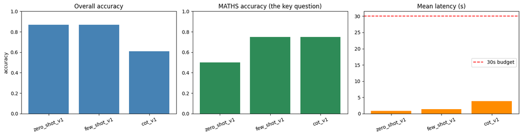

```python
import matplotlib.pyplot as plt

overall = accuracy_by(df, 'prompt_strategy').set_index('prompt_strategy')['accuracy']
maths_acc = accuracy_by(maths, 'prompt_strategy').set_index('prompt_strategy')['accuracy']
lat = df.groupby('prompt_strategy')['latency_s'].mean()
order = ['zero_shot_v1', 'few_shot_v1', 'cot_v1']

fig, ax = plt.subplots(1, 3, figsize=(15, 4))
ax[0].bar(order, [overall.get(s, 0) for s in order], color='steelblue')
ax[0].set_ylim(0, 1); ax[0].set_title('Overall accuracy'); ax[0].set_ylabel('accuracy')
ax[1].bar(order, [maths_acc.get(s, 0) for s in order], color='seagreen')
ax[1].set_ylim(0, 1); ax[1].set_title('MATHS accuracy (the key question)')
ax[2].bar(order, [lat.get(s, 0) for s in order], color='darkorange')
ax[2].axhline(30.0, color='red', linestyle='--', label='30s budget')
ax[2].set_title('Mean latency (s)'); ax[2].legend()
for a in ax:
    a.tick_params(axis='x', rotation=20)
plt.tight_layout(); plt.show()
```

```python
miss = df[(df['correct'] == False)][['qid', 'topic', 'question_text', 'predicted_answer', 'gold_answer', 'confidence',
  'raw_output']]
import pandas as pd
pd.set_option('display.max_colwidth', None)
print(miss.to_string(index=False))
```

```
    qid                        topic                                                                                     question_text predicted_answer gold_answer  confidence                                                                                                                             …
dev-001           Science and Nature                                              Which planet in our solar system has the most moons?                A           B         1.0                                                                                                                             …
dev-005                        Maths                                                                      What is 17 multiplied by 13?                D           B         1.0                                                                                                                             …
dev-008                        Maths                                                                     What is 2 to the power of 10?                A           C         1.0                                                                                                                             …
dev-001           Science and Nature                                              Which planet in our solar system has the most moons?                A           B         1.0                                                                                                                             …
dev-008                        Maths                                                                     What is 2 to the power of 10?                A           C         1.0                                                                                                                             …
dev-022                         News                                Volodymyr Zelensky was elected President of Ukraine in which year?                B           C         1.0                                                                                                                             …
dev-001           Science and Nature                                              Which planet in our solar system has the most moons?                A           B         0.5                                                                                                                            S…
dev-004           Science and Nature                                            What is the speed of light in a vacuum, approximately?                A           D         0.5                                                                                                                             …
dev-007                        Maths If a rectangle has a length of 15 cm and a width of 8 cm, what is its area in square centimetres?                A           D         0.5                                                                                                  To find the area of a recta…
dev-011 Ancient History and Politics                                            Which ancient wonder was located in Alexandria, Egypt?                A           B         0.5 Step 1: The Colossus of Rhodes and the Temple of Artemis were located in other places, and the Hanging Gardens are considere…
dev-013                Entertainment                                                        Who directed the 1994 film 'Pulp Fiction'?                A           D         0.5                                                                            Step 1: Recall that 'Pulp Fiction' is a well-know…
dev-014                Entertainment                                Which band released the album 'The Dark Side of the Moon' in 1973?                A           C         0.5                                                              Step 1: The album 'The Dark Side of the Moon' was released by a…
dev-017    Philosophy and Psychology                                             Which ancient Greek philosopher wrote 'The Republic'?                A           C         0.5                                                Step 1: The Republic is a dialogue written by Plato that discusses justice, m…
dev-021                         News       The WHO declared COVID-19 a Public Health Emergency of International Concern in which year?                A           D         0.5                                                                                                                             …
dev-023                         News                     The United Kingdom officially left the European Union (Brexit) on which date?                A           B         0.5                   Step 1: The UK held a referendum in 2016 to leave the EU, but it didn't officially leave until later.\nSte…
```

## 5 · Read-off

This motivates §4 (adaptive routing) and the agentic-tools study in §5.

# §4 · Adaptive prompt routing — a small-LLM reasoning study *(the depth piece)*

The deeper question behind §3: for a small model, does routing each question to a prompt chosen for its *reasoning shape* beat forcing one universal prompt — and **when does explicit reasoning help vs hurt?** Four conditions (universal / generic-CoT / structured / adaptive) over a labelled 8-category reasoning set, with a category×condition heatmap, a latency-vs-accuracy view, a routing-accuracy check, and a failure taxonomy.

# 04 · Adaptive prompt routing — a small-LLM reasoning study

**Research question:** for a small model (Qwen2.5-7B-Instruct), does routing each question to a prompt chosen for its *reasoning shape* beat forcing one universal prompt on everything? And the deeper one: **when does explicit reasoning help, and when does it hurt?**

The motivating failure is real and on the leaderboard: the Maths run died at level 9 on a clock-chime *interval-counting* question — `cot_v2`'s hard "≤3 steps" brevity cap made the model **guess before it had counted**. That same cap is what keeps verbose stats questions from timing out. One prompt cannot serve both regimes — which is exactly the hypothesis this experiment tests.

We isolate ONE variable — the **prompt strategy** — and compare four conditions over a labelled 8-category reasoning set:

| condition | prompt |
| --- | --- |
| **A_universal** | one universal prompt (production `few_shot_v1`) |
| **B_generic_cot** | always plain "think step by step" |
| **C_structured** | always structured enumeration |
| **D_adaptive** | `ReasoningRouter` picks per question |

No retrieval, no calculator here — *only* the prompt changes between conditions, so the effect we measure is the prompt's alone.

## 2 · Load the labelled reasoning set

```python
from experiments.adaptive_routing import load_reasoning_eval

questions, categories = load_reasoning_eval('data/reasoning_eval.jsonl')
print(f'{len(questions)} questions; categories:')
from collections import Counter
for cat, n in sorted(Counter(categories.values()).items()):
    print(f'  {cat:<22} {n}')
print('\nThe motivating failure, ic-001:')
print(' ', next(q.text for q in questions if q.qid == 'ic-001')[:140], '...')
```

```
48 questions; categories:
  arithmetic             5
  commonsense            5
  discrete_enumeration   5
  factual_qa             5
  interval_counting      5
  logical_reasoning      13
  multi_hop              5
  temporal_reasoning     5

The motivating failure, ic-001:
  If a clock chimes every hour the same number of times as the hour it is (e.g., at 3 P.M. it chimes 3 times) and once for every 15-minute inc ...
```

## 3 · Pick the engine

**Real run (Colab GPU):** `TransformersEngine` loads Qwen2.5-7B 4-bit — the numbers are real.

**Local / no-GPU:** `SimulatedReasoningEngine` — a **deterministic fixture, NOT a model**. Its correctness comes from a hand-set skill table that *encodes the hypothesis*, so it validates the **harness** (routing, logging, metrics, figures) end-to-end. It does **not** produce real findings.

```python
USE_REAL_MODEL = True   # set False to force the simulated fixture

engine = None
if USE_REAL_MODEL:
    try:
        from inference.engine import TransformersEngine
        from config import RunConfig
        cfg = RunConfig.from_yaml('configs/live.yaml')
        engine = TransformersEngine(cfg.model.name, cfg.model.quantization, cfg.model.dtype)
        engine.warmup()
        print('REAL engine loaded:', engine.name)
    except Exception as e:
        print(f'Real engine unavailable ({type(e).__name__}: {e})')
        print('-> falling back to the SIMULATED fixture.')
        engine = None

if engine is None:
    from inference.engine import SimulatedReasoningEngine
    engine = SimulatedReasoningEngine(questions, categories)
    print('\n' + '!' * 72)
    print('!! SIMULATED FIXTURE ENGINE -- validates the HARNESS, not the model.   !!')
    print('!! Real findings need USE_REAL_MODEL=True on a Colab GPU runtime.      !!')
    print('!' * 72)
```

```
[transformers] `torch_dtype` is deprecated! Use `dtype` instead!
```

```
Downloading (incomplete total...): 0.00B [00:00, ?B/s]
```

```
REAL engine loaded: Qwen/Qwen2.5-7B-Instruct
```

Writes one `experiments/adaptive_routing/records.jsonl` (strategy chosen, router verdict, correctness, latency, tokens, reasoning length, raw output).

```python
from experiments.adaptive_routing import AdaptiveRoutingExperiment

# max_new_tokens=512 (vs the 256 default): the game allows 130s/question, so a longer cap is free and
# fixes the no_answer_parsed truncations where verbose chains never reached the 'Answer:' line.
exp = AdaptiveRoutingExperiment(engine, max_new_tokens=512)
records_path = exp.run(questions, categories, verbose=True)
records_path
```

```
=== Condition A_universal: Single universal prompt (production few_shot_v1) ===
```

```
  [1/192] ic-001  A_universal    strat=few_shot_v1                 -> B (gold C) [  X]
  [2/192] ic-002  A_universal    strat=few_shot_v1                 -> B (gold B) [ok ]
  [3/192] ic-003  A_universal    strat=few_shot_v1                 -> C (gold B) [  X]
  [4/192] ic-004  A_universal    strat=few_shot_v1                 -> C (gold C) [ok ]
  [5/192] ic-005  A_universal    strat=few_shot_v1                 -> B (gold B) [ok ]
  [6/192] tr-001  A_universal    strat=few_shot_v1                 -> A (gold B) [  X]
  [7/192] tr-002  A_universal    strat=few_shot_v1                 -> C (gold B) [  X]
  [8/192] tr-003  A_universal    strat=few_shot_v1                 -> A (gold A) [ok ]
  [9/192] tr-004  A_universal    strat=few_shot_v1                 -> B (gold B) [ok ]
  [10/192] tr-005  A_universal    strat=few_shot_v1                 -> B (gold B) [ok ]
  [11/192] de-001  A_universal    strat=few_shot_v1                 -> C (gold C) [ok ]
  [12/192] de-002  A_universal    strat=few_shot_v1                 -> A (gold B) [  X]
  [13/192] de-003  A_universal    strat=few_shot_v1                 -> B (gold B) [ok ]
  [14/192] de-004  A_universal    strat=few_shot_v1                 -> D (gold B) [  X]
  [15/192] de-005  A_universal    strat=few_shot_v1                 -> B (gold B) [ok ]
  [16/192] ar-001  A_universal    strat=few_shot_v1                 -> C (gold C) [ok ]
  [17/192] ar-002  A_universal    strat=few_shot_v1                 -> B (gold B) [ok ]
  [18/192] ar-003  A_universal    strat=few_shot_v1                 -> B (gold A) [  X]
  [19/192] ar-004  A_universal    strat=few_shot_v1                 -> B (gold B) [ok ]
  [20/192] ar-005  A_universal    strat=few_shot_v1                 -> A (gold B) [  X]
  [21/192] fa-001  A_universal    strat=few_shot_v1                 -> C (gold C) [ok ]
  [22/192] fa-002  A_universal    strat=few_shot_v1                 -> C (gold C) [ok ]
  [23/192] fa-003  A_universal    strat=few_shot_v1                 -> B (gold B) [ok ]
  [24/192] fa-004  A_universal    strat=few_shot_v1                 -> C (gold C) [ok ]
  [25/192] fa-005  A_universal    strat=few_shot_v1                 -> C (gold C) [ok ]
  [26/192] cs-001  A_universal    strat=few_shot_v1                 -> B (gold B) [ok ]
  [27/192] cs-002  A_universal    strat=few_shot_v1                 -> C (gold C) [ok ]
  [28/192] cs-003  A_universal    strat=few_shot_v1                 -> B (gold B) [ok ]
  [29/192] cs-004  A_universal    strat=few_shot_v1                 -> B (gold B) [ok ]
  [30/192] cs-005  A_universal    strat=few_shot_v1                 -> B (gold B) [ok ]
  [31/192] lr-001  A_universal    strat=few_shot_v1                 -> B (gold D) [  X]
  [32/192] lr-002  A_universal    strat=few_shot_v1                 -> B (gold B) [ok ]
  [33/192] lr-003  A_universal    strat=few_shot_v1                 -> B (gold B) [ok ]
  [34/192] lr-004  A_universal    strat=few_shot_v1                 -> B (gold B) [ok ]
  [35/192] lr-005  A_universal    strat=few_shot_v1                 -> B (gold B) [ok ]
  [36/192] mh-001  A_universal    strat=few_shot_v1                 -> B (gold B) [ok ]
  [37/192] mh-002  A_universal    strat=few_shot_v1                 -> B (gold C) [  X]
  [38/192] mh-003  A_universal    strat=few_shot_v1                 -> B (gold B) [ok ]
  [39/192] mh-004  A_universal    strat=few_shot_v1                 -> B (gold B) [ok ]
  [40/192] mh-005  A_universal    strat=few_shot_v1                 -> C (gold C) [ok ]
```

[output cut: 145 more lines]

```
  [180/192] mh-001  D_adaptive     strat=checklist_cot               -> B (gold B) [ok ]
  [181/192] mh-002  D_adaptive     strat=checklist_cot               -> C (gold C) [ok ]
  [182/192] mh-003  D_adaptive     strat=checklist_cot               -> B (gold B) [ok ]
  [183/192] mh-004  D_adaptive     strat=checklist_cot               -> B (gold B) [ok ]
  [184/192] mh-005  D_adaptive     strat=checklist_cot               -> C (gold C) [ok ]
  [185/192] log-ind-001 D_adaptive     strat=checklist_cot               -> A (gold D) [  X]
  [186/192] log-ind-002 D_adaptive     strat=checklist_cot               -> A (gold A) [ok ]
  [187/192] log-ind-003 D_adaptive     strat=checklist_cot               -> B (gold C) [  X]
  [188/192] log-ind-004 D_adaptive     strat=checklist_cot               -> B (gold B) [ok ]
  [189/192] log-ind-005 D_adaptive     strat=checklist_cot               -> D (gold D) [ok ]
  [190/192] log-stat-001 D_adaptive     strat=checklist_cot               -> B (gold B) [ok ]
  [191/192] log-stat-002 D_adaptive     strat=checklist_cot               -> A (gold A) [ok ]
  [192/192] log-stat-003 D_adaptive     strat=generic_cot                 -> C (gold C) [ok ]

Wrote 192 records -> experiments/adaptive_routing/records.jsonl
```

```
'experiments/adaptive_routing/records.jsonl'
```

### 🔬 Core implementation: adaptive routing (category -> strategy) + a deterministic Maths solver

**(a) Reasoning-shape routing** (`src/classify/reasoning_router.py`) -- first sort the question into one of 8 reasoning shapes, then pick the prompt from a policy table. The whole thing is `route()` (three lines) + one policy table:

```
def route(self, question: Question) -> tuple[ReasoningSignal, str]:
    signal   = self.classifier.classify(question)                 # 8 classes: arithmetic / temporal /
    strategy = self.policy.get(signal.category, self.fallback)    #   interval_counting / discrete_enum /
    return signal, strategy                                       #   factual_qa / commonsense / logical / multi_hop

DEFAULT_ROUTING_POLICY = {
    # recall/commonsense: an explicit chain HURTS (hallucinated justification, drift) -> answer directly
    FACTUAL_QA: "direct_answer",  COMMONSENSE: "direct_answer",
    ARITHMETIC: "generic_cot",                                    # pure computation: take steps, don't over-enumerate
    TEMPORAL_REASONING:   "structured_enumeration_cot",          # list events/cases in order THEN count ->
    INTERVAL_COUNTING:    "structured_enumeration_cot",          #   enumerate first (the clock-chime 0.4->1.0 fix)
    DISCRETE_ENUMERATION: "structured_enumeration_cot",
    LOGICAL_REASONING: "checklist_cot",  MULTI_HOP: "checklist_cot",  # multi-clause/validity: a per-item checklist
}
```

`RoutingPromptBuilder` is a duck-type of `PromptBuilder`: the pipeline still only calls `.build()` and reads `.strategy`, but the strategy **varies per question** (the EvalRecord logs which prompt actually ran). Live Maths uses a **conservative policy**: only the counting/temporal shapes with offline evidence are re-routed; everything else stays on the battle-tested `cot_v2`, keeping regression risk minimal.

**(b) Deterministic Maths solver** (`src/tools/math_solvers.py`) -- runs **before** the LLM; on a hit (single option, correct by construction) it answers directly and skips the model; otherwise it abstains (returns None) and the LLM path is untouched -- it can only **add** correct answers, never overwrite the model:

```
_SOLVERS = (_solve_finite_field_roots, _solve_ring_characteristic, _solve_gcd,
            _solve_common_divisor_count, _solve_subspace_intersection_dim, _solve_sum_product,
            _solve_reflection_yx, _solve_triangle_sides, _solve_percentage_increase,
            _solve_operator_placement, _solve_weekday, _solve_parallelogram_angle, _solve_arith_expression)

def solve_maths(question: Question):
    if not question.options: return None                 # MCQ only
    q = _norm(question)                                   # normalise unicode minus/dashes first
    for fn in _SOLVERS:                                   # each type-specific solver in turn
        try: res = fn(q)
        except Exception: res = None                      # crash-safe: an exception counts as abstain
        if res is not None: return res                    # first deterministic hit wins
    return None                                           # all abstain -> hand off to the LLM
```

## 5 · Headline — does adaptive (D) beat the rest, and at what cost?

```python
import pandas as pd
from experiments import analysis
pd.set_option('display.width', 170); pd.set_option('display.max_columns', 20)

df = analysis.load_records(records_path)
comp = analysis.strategy_comparison_table(df)
comp.round(3)
```

|  | condition | accuracy | n | mean_latency_s | p95_latency_s | mean_tokens_out | mean_reasoning_lines |
| --- | --- | --- | --- | --- | --- | --- | --- |
| 0 | A_universal | 0.771 | 48 | 1.452 | 1.662 | 2.000 | 1.000 |
| 1 | B_generic_cot | 0.875 | 48 | 19.597 | 37.243 | 224.333 | 10.854 |
| 2 | C_structured | 0.938 | 48 | 13.727 | 24.616 | 147.500 | 11.833 |
| 3 | D_adaptive | 0.917 | 48 | 16.835 | 35.758 | 186.583 | 11.875 |

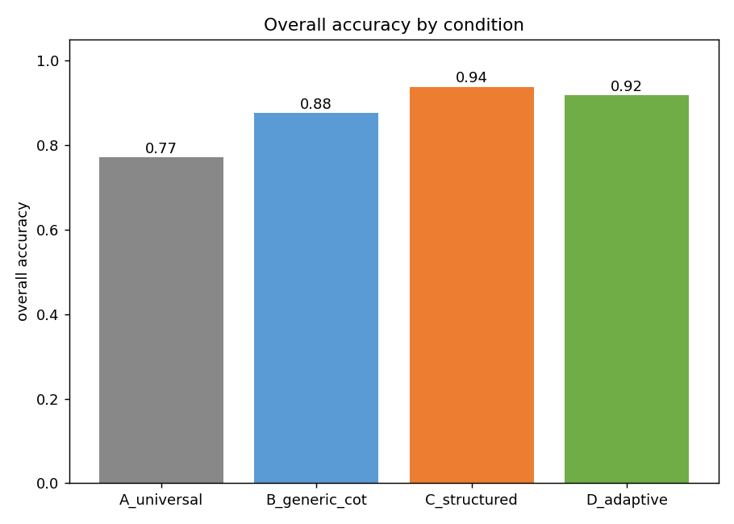

```python
from IPython.display import Image, display
analysis.plot_condition_accuracy_bars(df)
display(Image('experiments/adaptive_routing/fig_condition_accuracy.png'))
```

## 6 · WHERE each prompt helps or hurts — category × condition heatmap

The whole hypothesis in one figure: a prompt that is green on one row can be red on another.

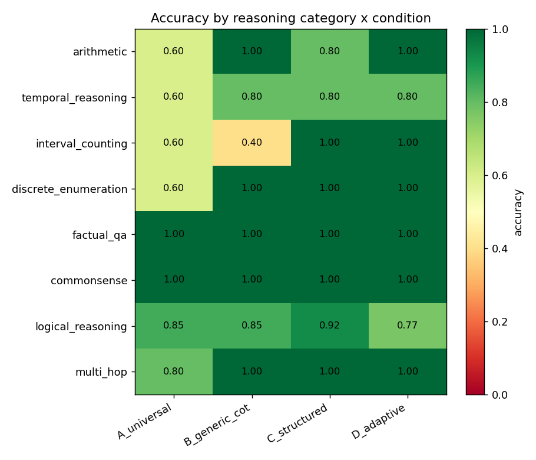

| condition true_category | A_universal | B_generic_cot | C_structured | D_adaptive |
| --- | --- | --- | --- | --- |
| arithmetic | 0.60 | 1.00 | 0.80 | 1.00 |
| temporal_reasoning | 0.60 | 0.80 | 0.80 | 0.80 |
| interval_counting | 0.60 | 0.40 | 1.00 | 1.00 |
| discrete_enumeration | 0.60 | 1.00 | 1.00 | 1.00 |
| factual_qa | 1.00 | 1.00 | 1.00 | 1.00 |
| commonsense | 1.00 | 1.00 | 1.00 | 1.00 |
| logical_reasoning | 0.85 | 0.85 | 0.92 | 0.77 |
| multi_hop | 0.80 | 1.00 | 1.00 | 1.00 |

```python
analysis.plot_category_heatmap(df)
display(Image('experiments/adaptive_routing/fig_category_heatmap.png'))
analysis.category_accuracy_matrix(df).round(2)
```

## 7 · The cost of reasoning — latency vs accuracy

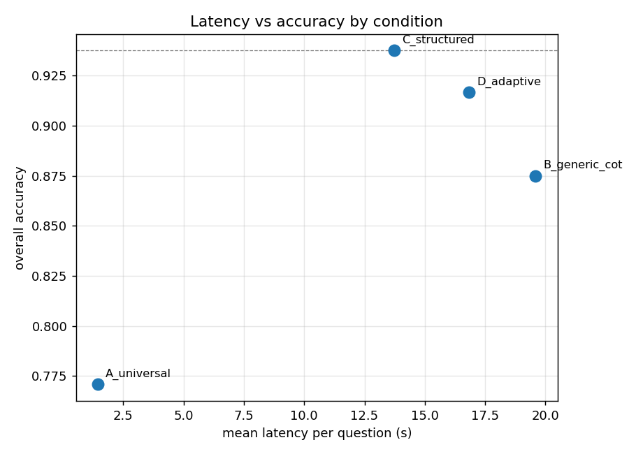

```python
analysis.plot_latency_accuracy(df)
display(Image('experiments/adaptive_routing/fig_latency_accuracy.png'))
```

## 8 · The oracle the router chases — best fixed strategy per category

If the per-category best fixed strategy and the adaptive arm agree, the router is doing its job.

```python
analysis.best_strategy_per_category(df)
```

|  | category | best_strategy | best_accuracy | adaptive_accuracy |
| --- | --- | --- | --- | --- |
| 0 | arithmetic | generic_cot | 1.000000 | 1.000000 |
| 1 | temporal_reasoning | generic_cot | 0.800000 | 0.800000 |
| 2 | interval_counting | structured_enumeration_cot | 1.000000 | 1.000000 |
| 3 | discrete_enumeration | generic_cot | 1.000000 | 1.000000 |
| 4 | factual_qa | direct_answer | 1.000000 | 1.000000 |
| 5 | commonsense | direct_answer | 1.000000 | 1.000000 |
| 6 | logical_reasoning | structured_enumeration_cot | 0.923077 | 0.769231 |
| 7 | multi_hop | checklist_cot | 1.000000 | 1.000000 |

## 9 · Did the classifier label the reasoning shape correctly?

Routing accuracy + a confusion table (true category vs the category the classifier inferred).

```python
rep = analysis.routing_report(df)
print('overall routing accuracy:', round(rep['overall_routing_accuracy'], 3))
rep['confusion']
```

```
overall routing accuracy: 0.979
```

| routed_category true_category | arithmetic | temporal_reasoning | interval_counting | discrete_enumeration | factual_qa | commonsense | logical_reasoning | multi_hop |
| --- | --- | --- | --- | --- | --- | --- | --- | --- |
| arithmetic | 5 | 0 | 0 | 0 | 0 | 0 | 0 | 0 |
| temporal_reasoning | 0 | 5 | 0 | 0 | 0 | 0 | 0 | 0 |
| interval_counting | 0 | 0 | 5 | 0 | 0 | 0 | 0 | 0 |
| discrete_enumeration | 0 | 0 | 0 | 5 | 0 | 0 | 0 | 0 |
| factual_qa | 0 | 0 | 0 | 0 | 5 | 0 | 0 | 0 |
| commonsense | 0 | 0 | 0 | 0 | 0 | 5 | 0 | 0 |
| logical_reasoning | 1 | 0 | 0 | 0 | 0 | 0 | 12 | 0 |
| multi_hop | 0 | 0 | 0 | 0 | 0 | 0 | 0 | 5 |

## 10 · Failure taxonomy — *why* each prompt got things wrong

Heuristic labels from the raw output: overthinking (recall Q over-reasoned), boundary_error (counting off-by-one), skipped_case (never enumerated), arithmetic_drift, no_answer_parsed, hallucinated/other.

```python
analysis.failure_taxonomy(df)
```

| failure_mode condition | boundary_error | hallucinated/other | no_answer_parsed | skipped_case |
| --- | --- | --- | --- | --- |
| A_universal | 0 | 0 | 0 | 11 |
| B_generic_cot | 3 | 2 | 1 | 0 |
| C_structured | 1 | 1 | 1 | 0 |
| D_adaptive | 1 | 2 | 1 | 0 |

## 11 · Findings & recommendation

**Recommendation for the live game:** for the live **Maths** pipeline (§8), use a per-question router that sends interval-counting / temporal / enumeration questions to `structured_enumeration_cot` and leaves concept/stats questions on the current chain — exactly the regime split `cot_v2`'s single brevity cap conflated.

## 12 · Focused A/B — the level-11 induction death (logic questions)

The live Maths run got past the counting deaths (structured routing worked) and died at **level 11** on a strong-induction question (`log-ind-001`, the real qid 6737): `cot_v2` wrote a 24-token wrong one-liner ("n0 is a counterexample, so all higher values are also counterexamples") — its **brevity cap gagged the reasoning**, the same root cause as the clock-chime death.

This section pits four prompts over the **logic questions** (the original `lr-*`, five induction / contrapositive `log-ind-*`, and three "which-of-the-following-is-true" stats look-alikes `log-stat-*`):

| arm | prompt |
| --- | --- |
| `cot_v2` | the current Maths fallback (≤3-step brevity cap) |
| `generic_cot` | step-by-step, **no** cap |
| `checklist_cot` | per-option verification checklist |
| `checklist_sc5` | checklist + **self-consistency** vote (n=5) — affordable under the 130s budget |

**Decision rule:** adopt the arm that fixes the induction (`log-ind-*`) questions **without** regressing the stats (`log-stat-*`) ones (those currently win on `cot_v2`).

```python
from experiments.adaptive_routing import AdaptiveRoutingExperiment, LOGIC_FOCUS_CONDITIONS

# All logic questions (lr-* + log-ind-* + log-stat-*). Same engine as above (real Qwen on Colab).
logic_qs = [q for q in questions if categories[q.qid] == 'logical_reasoning']
print(f'{len(logic_qs)} logic questions:', [q.qid for q in logic_qs])

logic_exp = AdaptiveRoutingExperiment(
    engine, conditions=LOGIC_FOCUS_CONDITIONS,
    out_dir='experiments/adaptive_routing_logic', max_new_tokens=512,
)
logic_path = logic_exp.run(logic_qs, categories, verbose=True)
logic_path
```

```
13 logic questions: ['lr-001', 'lr-002', 'lr-003', 'lr-004', 'lr-005', 'log-ind-001', 'log-ind-002', 'log-ind-003', 'log-ind-004', 'log-ind-005', 'log-stat-001', 'log-stat-002', 'log-stat-003']

=== Condition cot_v2: The current Maths fallback (=3-step brevity cap) ===
```

```
  [1/52] lr-001  cot_v2         strat=cot_v2                      -> B (gold D) [  X]
  [2/52] lr-002  cot_v2         strat=cot_v2                      -> B (gold B) [ok ]
  [3/52] lr-003  cot_v2         strat=cot_v2                      -> B (gold B) [ok ]
  [4/52] lr-004  cot_v2         strat=cot_v2                      -> B (gold B) [ok ]
  [5/52] lr-005  cot_v2         strat=cot_v2                      -> B (gold B) [ok ]
  [6/52] log-ind-001 cot_v2         strat=cot_v2                      -> C (gold D) [  X]
  [7/52] log-ind-002 cot_v2         strat=cot_v2                      -> A (gold A) [ok ]
  [8/52] log-ind-003 cot_v2         strat=cot_v2                      -> C (gold C) [ok ]
  [9/52] log-ind-004 cot_v2         strat=cot_v2                      -> B (gold B) [ok ]
  [10/52] log-ind-005 cot_v2         strat=cot_v2                      -> D (gold D) [ok ]
  [11/52] log-stat-001 cot_v2         strat=cot_v2                      -> B (gold B) [ok ]
  [12/52] log-stat-002 cot_v2         strat=cot_v2                      -> A (gold A) [ok ]
  [13/52] log-stat-003 cot_v2         strat=cot_v2                      -> C (gold C) [ok ]

=== Condition generic_cot: Step-by-step, NO brevity cap ===
  [14/52] lr-001  generic_cot    strat=generic_cot                 -> B (gold D) [  X]
  [15/52] lr-002  generic_cot    strat=generic_cot                 -> B (gold B) [ok ]
  [16/52] lr-003  generic_cot    strat=generic_cot                 -> B (gold B) [ok ]
  [17/52] lr-004  generic_cot    strat=generic_cot                 -> B (gold B) [ok ]
  [18/52] lr-005  generic_cot    strat=generic_cot                 -> B (gold B) [ok ]
  [19/52] log-ind-001 generic_cot    strat=generic_cot                 -> C (gold D) [  X]
  [20/52] log-ind-002 generic_cot    strat=generic_cot                 -> A (gold A) [ok ]
  [21/52] log-ind-003 generic_cot    strat=generic_cot                 -> C (gold C) [ok ]
  [22/52] log-ind-004 generic_cot    strat=generic_cot                 -> B (gold B) [ok ]
  [23/52] log-ind-005 generic_cot    strat=generic_cot                 -> D (gold D) [ok ]
  [24/52] log-stat-001 generic_cot    strat=generic_cot                 -> B (gold B) [ok ]
  [25/52] log-stat-002 generic_cot    strat=generic_cot                 -> A (gold A) [ok ]
  [26/52] log-stat-003 generic_cot    strat=generic_cot                 -> C (gold C) [ok ]

=== Condition checklist_cot: Per-option verification checklist ===
  [27/52] lr-001  checklist_cot  strat=checklist_cot               -> B (gold D) [  X]
  [28/52] lr-002  checklist_cot  strat=checklist_cot               -> B (gold B) [ok ]
  [29/52] lr-003  checklist_cot  strat=checklist_cot               -> B (gold B) [ok ]
  [30/52] lr-004  checklist_cot  strat=checklist_cot               -> B (gold B) [ok ]
  [31/52] lr-005  checklist_cot  strat=checklist_cot               -> B (gold B) [ok ]
  [32/52] log-ind-001 checklist_cot  strat=checklist_cot               -> A (gold D) [  X]
  [33/52] log-ind-002 checklist_cot  strat=checklist_cot               -> A (gold A) [ok ]
  [34/52] log-ind-003 checklist_cot  strat=checklist_cot               -> B (gold C) [  X]
  [35/52] log-ind-004 checklist_cot  strat=checklist_cot               -> B (gold B) [ok ]
  [36/52] log-ind-005 checklist_cot  strat=checklist_cot               -> D (gold D) [ok ]
  [37/52] log-stat-001 checklist_cot  strat=checklist_cot               -> B (gold B) [ok ]
  [38/52] log-stat-002 checklist_cot  strat=checklist_cot               -> A (gold A) [ok ]
  [39/52] log-stat-003 checklist_cot  strat=checklist_cot               -> C (gold C) [ok ]

=== Condition checklist_sc5: Checklist + self-consistency vote (n=5) ===
  [40/52] lr-001  checklist_sc5  strat=checklist_cot               -> B (gold D) [  X]
  [41/52] lr-002  checklist_sc5  strat=checklist_cot               -> B (gold B) [ok ]
  [42/52] lr-003  checklist_sc5  strat=checklist_cot               -> B (gold B) [ok ]
  [43/52] lr-004  checklist_sc5  strat=checklist_cot               -> D (gold B) [  X]
  [44/52] lr-005  checklist_sc5  strat=checklist_cot               -> B (gold B) [ok ]
  [45/52] log-ind-001 checklist_sc5  strat=checklist_cot               -> C (gold D) [  X]
  [46/52] log-ind-002 checklist_sc5  strat=checklist_cot               -> A (gold A) [ok ]
  [47/52] log-ind-003 checklist_sc5  strat=checklist_cot               -> C (gold C) [ok ]
  [48/52] log-ind-004 checklist_sc5  strat=checklist_cot               -> B (gold B) [ok ]
  [49/52] log-ind-005 checklist_sc5  strat=checklist_cot               -> D (gold D) [ok ]
  [50/52] log-stat-001 checklist_sc5  strat=checklist_cot               -> B (gold B) [ok ]
  [51/52] log-stat-002 checklist_sc5  strat=checklist_cot               -> A (gold A) [ok ]
  [52/52] log-stat-003 checklist_sc5  strat=checklist_cot               -> C (gold C) [ok ]

Wrote 52 records -> experiments/adaptive_routing_logic/records.jsonl
```

```
'experiments/adaptive_routing_logic/records.jsonl'
```

### 12.1 · Per-condition accuracy on logic questions

```python
import pandas as pd
ldf = analysis.load_records(logic_path)
order = [c.name for c in LOGIC_FOCUS_CONDITIONS]
ldf.groupby('condition')['correct'].agg(accuracy='mean', n='count').reindex(order)
```

| condition | accuracy | n |
| --- | --- | --- |
| cot_v2 | 0.846154 | 13 |
| generic_cot | 0.846154 | 13 |
| checklist_cot | 0.769231 | 13 |
| checklist_sc5 | 0.769231 | 13 |

### 12.2 · Per-question correctness (the decision table)

`1.0` = correct. Look at the `log-ind-*` rows (does a prompt fix the induction death?) vs the `log-stat-*` rows (does it regress the stats look-alikes?).

```python
piv = ldf.pivot_table(index='qid', columns='condition', values='correct').reindex(columns=order)
# order rows: induction first, then stats, then the original lr-*
row_order = [q.qid for q in logic_qs]
piv = piv.reindex(row_order)
piv
```

| condition qid | cot_v2 | generic_cot | checklist_cot | checklist_sc5 |
| --- | --- | --- | --- | --- |
| lr-001 | 0.0 | 0.0 | 0.0 | 0.0 |
| lr-002 | 1.0 | 1.0 | 1.0 | 1.0 |
| lr-003 | 1.0 | 1.0 | 1.0 | 1.0 |
| lr-004 | 1.0 | 1.0 | 1.0 | 0.0 |
| lr-005 | 1.0 | 1.0 | 1.0 | 1.0 |
| log-ind-001 | 0.0 | 0.0 | 0.0 | 0.0 |
| log-ind-002 | 1.0 | 1.0 | 1.0 | 1.0 |
| log-ind-003 | 1.0 | 1.0 | 0.0 | 1.0 |
| log-ind-004 | 1.0 | 1.0 | 1.0 | 1.0 |
| log-ind-005 | 1.0 | 1.0 | 1.0 | 1.0 |
| log-stat-001 | 1.0 | 1.0 | 1.0 | 1.0 |
| log-stat-002 | 1.0 | 1.0 | 1.0 | 1.0 |
| log-stat-003 | 1.0 | 1.0 | 1.0 | 1.0 |

### 12.3 · Read-out & decision

- If `checklist_cot` (or `checklist_sc5`) flips `log-ind-001` (qid 6737) and the other `log-ind-*` to correct **while keeping every `log-stat-*` correct**, then change the live Maths policy so `logical_reasoning -> checklist_cot` (edit `MATHS_LIVE_POLICY` in `src/classify/reasoning_router.py`).
- If checklist **regresses** the stats questions, keep `cot_v2` for them and consider self-consistency on `cot_v2` instead, or a finer classifier split (induction vs stats-conclusion).
- The classifier already routes induction questions to `logical_reasoning` (fixed this turn — they used to leak to `arithmetic` via the incidental `+1`), so whatever wins here can actually be targeted live.

## 13 · Probe — does explicit logical-DIRECTION prompting break the induction ceiling?

**Go/no-go:** if `implication_cot` flips `log-ind-001` (= 6737), `lr-001`, or `log-ind-003` that the others miss, the directional hypothesis is worth the full build (trap-labelled dataset + failure logging). If it moves nothing, 6737 is a capability ceiling and we stop.

```python
from experiments.adaptive_routing import AdaptiveRoutingExperiment, IMPLICATION_PROBE_CONDITIONS

logic_qs = [q for q in questions if categories[q.qid] == 'logical_reasoning']
probe_path = AdaptiveRoutingExperiment(
    engine, conditions=IMPLICATION_PROBE_CONDITIONS,
    out_dir='experiments/adaptive_routing_implication', max_new_tokens=512,
).run(logic_qs, categories, verbose=True)
probe_path
```

```
=== Condition cot_v2: Current Maths fallback (brevity-capped) ===
```

```
  [1/52] lr-001  cot_v2         strat=cot_v2                      -> B (gold D) [  X]
  [2/52] lr-002  cot_v2         strat=cot_v2                      -> B (gold B) [ok ]
  [3/52] lr-003  cot_v2         strat=cot_v2                      -> B (gold B) [ok ]
  [4/52] lr-004  cot_v2         strat=cot_v2                      -> B (gold B) [ok ]
  [5/52] lr-005  cot_v2         strat=cot_v2                      -> B (gold B) [ok ]
  [6/52] log-ind-001 cot_v2         strat=cot_v2                      -> C (gold D) [  X]
  [7/52] log-ind-002 cot_v2         strat=cot_v2                      -> A (gold A) [ok ]
  [8/52] log-ind-003 cot_v2         strat=cot_v2                      -> C (gold C) [ok ]
  [9/52] log-ind-004 cot_v2         strat=cot_v2                      -> B (gold B) [ok ]
  [10/52] log-ind-005 cot_v2         strat=cot_v2                      -> D (gold D) [ok ]
  [11/52] log-stat-001 cot_v2         strat=cot_v2                      -> B (gold B) [ok ]
  [12/52] log-stat-002 cot_v2         strat=cot_v2                      -> A (gold A) [ok ]
  [13/52] log-stat-003 cot_v2         strat=cot_v2                      -> C (gold C) [ok ]

=== Condition generic_cot: Step-by-step, no cap ===
  [14/52] lr-001  generic_cot    strat=generic_cot                 -> B (gold D) [  X]
  [15/52] lr-002  generic_cot    strat=generic_cot                 -> B (gold B) [ok ]
  [16/52] lr-003  generic_cot    strat=generic_cot                 -> B (gold B) [ok ]
  [17/52] lr-004  generic_cot    strat=generic_cot                 -> B (gold B) [ok ]
  [18/52] lr-005  generic_cot    strat=generic_cot                 -> B (gold B) [ok ]
  [19/52] log-ind-001 generic_cot    strat=generic_cot                 -> C (gold D) [  X]
  [20/52] log-ind-002 generic_cot    strat=generic_cot                 -> A (gold A) [ok ]
  [21/52] log-ind-003 generic_cot    strat=generic_cot                 -> C (gold C) [ok ]
  [22/52] log-ind-004 generic_cot    strat=generic_cot                 -> B (gold B) [ok ]
  [23/52] log-ind-005 generic_cot    strat=generic_cot                 -> D (gold D) [ok ]
  [24/52] log-stat-001 generic_cot    strat=generic_cot                 -> B (gold B) [ok ]
  [25/52] log-stat-002 generic_cot    strat=generic_cot                 -> A (gold A) [ok ]
  [26/52] log-stat-003 generic_cot    strat=generic_cot                 -> C (gold C) [ok ]

=== Condition checklist_cot: Per-option verification checklist ===
  [27/52] lr-001  checklist_cot  strat=checklist_cot               -> B (gold D) [  X]
  [28/52] lr-002  checklist_cot  strat=checklist_cot               -> B (gold B) [ok ]
  [29/52] lr-003  checklist_cot  strat=checklist_cot               -> B (gold B) [ok ]
  [30/52] lr-004  checklist_cot  strat=checklist_cot               -> B (gold B) [ok ]
  [31/52] lr-005  checklist_cot  strat=checklist_cot               -> B (gold B) [ok ]
  [32/52] log-ind-001 checklist_cot  strat=checklist_cot               -> A (gold D) [  X]
  [33/52] log-ind-002 checklist_cot  strat=checklist_cot               -> A (gold A) [ok ]
  [34/52] log-ind-003 checklist_cot  strat=checklist_cot               -> B (gold C) [  X]
  [35/52] log-ind-004 checklist_cot  strat=checklist_cot               -> B (gold B) [ok ]
  [36/52] log-ind-005 checklist_cot  strat=checklist_cot               -> D (gold D) [ok ]
  [37/52] log-stat-001 checklist_cot  strat=checklist_cot               -> B (gold B) [ok ]
  [38/52] log-stat-002 checklist_cot  strat=checklist_cot               -> A (gold A) [ok ]
  [39/52] log-stat-003 checklist_cot  strat=checklist_cot               -> C (gold C) [ok ]

=== Condition implication_cot: Explicit logical-direction scaffold (P->Q, contrapositive) ===
  [40/52] lr-001  implication_cot strat=implication_cot             -> B (gold D) [  X]
  [41/52] lr-002  implication_cot strat=implication_cot             -> B (gold B) [ok ]
  [42/52] lr-003  implication_cot strat=implication_cot             -> B (gold B) [ok ]
  [43/52] lr-004  implication_cot strat=implication_cot             -> B (gold B) [ok ]
  [44/52] lr-005  implication_cot strat=implication_cot             -> B (gold B) [ok ]
  [45/52] log-ind-001 implication_cot strat=implication_cot             -> C (gold D) [  X]
  [46/52] log-ind-002 implication_cot strat=implication_cot             -> A (gold A) [ok ]
  [47/52] log-ind-003 implication_cot strat=implication_cot             -> C (gold C) [ok ]
  [48/52] log-ind-004 implication_cot strat=implication_cot             -> B (gold B) [ok ]
  [49/52] log-ind-005 implication_cot strat=implication_cot             -> D (gold D) [ok ]
  [50/52] log-stat-001 implication_cot strat=implication_cot             -> B (gold B) [ok ]
  [51/52] log-stat-002 implication_cot strat=implication_cot             -> A (gold A) [ok ]
  [52/52] log-stat-003 implication_cot strat=implication_cot             -> C (gold C) [ok ]

Wrote 52 records -> experiments/adaptive_routing_implication/records.jsonl
```

```
'experiments/adaptive_routing_implication/records.jsonl'
```

### 13.1 · Per-condition accuracy + per-question decision table

```python
import pandas as pd
pdf = analysis.load_records(probe_path)
order = [c.name for c in IMPLICATION_PROBE_CONDITIONS]
display(pdf.groupby('condition')['correct'].agg(accuracy='mean', n='count').reindex(order))
piv = pdf.pivot_table(index='qid', columns='condition', values='correct').reindex(columns=order)
piv = piv.reindex([q.qid for q in logic_qs])
piv
```

| condition | accuracy | n |
| --- | --- | --- |
| cot_v2 | 0.846154 | 13 |
| generic_cot | 0.846154 | 13 |
| checklist_cot | 0.769231 | 13 |
| implication_cot | 0.846154 | 13 |

| condition qid | cot_v2 | generic_cot | checklist_cot | implication_cot |
| --- | --- | --- | --- | --- |
| lr-001 | 0.0 | 0.0 | 0.0 | 0.0 |
| lr-002 | 1.0 | 1.0 | 1.0 | 1.0 |
| lr-003 | 1.0 | 1.0 | 1.0 | 1.0 |
| lr-004 | 1.0 | 1.0 | 1.0 | 1.0 |
| lr-005 | 1.0 | 1.0 | 1.0 | 1.0 |
| log-ind-001 | 0.0 | 0.0 | 0.0 | 0.0 |
| log-ind-002 | 1.0 | 1.0 | 1.0 | 1.0 |
| log-ind-003 | 1.0 | 1.0 | 0.0 | 1.0 |
| log-ind-004 | 1.0 | 1.0 | 1.0 | 1.0 |
| log-ind-005 | 1.0 | 1.0 | 1.0 | 1.0 |
| log-stat-001 | 1.0 | 1.0 | 1.0 | 1.0 |
| log-stat-002 | 1.0 | 1.0 | 1.0 | 1.0 |
| log-stat-003 | 1.0 | 1.0 | 1.0 | 1.0 |

### 13.2 · The decisive rows — did the scaffold fix what the others missed?

```python
# Focus on the questions the other prompts FAIL: 6737 (log-ind-001), lr-001, log-ind-003.
focus = ['log-ind-001', 'lr-001', 'log-ind-003']
print(piv.reindex(focus).to_string())
print()
for qid in focus:
    row = pdf[(pdf.qid==qid) & (pdf.condition=='implication_cot')]
    if len(row):
        r = row.iloc[0]
        print(f'=== {qid}  implication_cot -> {r.predicted_answer} (gold {r.gold_answer})  '
              f'{"CORRECT" if r.correct else "WRONG"} ===')
        print(r.raw_output[:700]); print()
```

```
condition    cot_v2  generic_cot  checklist_cot  implication_cot
qid
log-ind-001     0.0          0.0            0.0              0.0
lr-001          0.0          0.0            0.0              0.0
log-ind-003     1.0          1.0            0.0              1.0

=== log-ind-001  implication_cot -> C (gold D)  WRONG ===
The given conditions imply that if \( S(k) \) is false for some \( k \geq n_0 \), then \( S(k-1) \) must also be false, and this logic propagates backward. This means that once \( S(n_0) \) is false, all previous statements \( S(n) \) for \( n < n_0 \) must also be false.

Let's test each option:

A) \( S(n_0 - 1) \) is not true.
   - This is not necessarily true because we only know that \( S(n_0) \) is false, but we don't have information about \( S(n_0 - 1) \).

B) \( S(n_0 + 1) \) is not true.
   - This is not necessarily true because the problem does not provide information about \( S(n_0 + 1) \).

C) \( S(n) \) is not true for any \( n \geq n_0 \).
   - This is true based on the given

=== lr-001  implication_cot -> B (gold D)  WRONG ===
1. The given statements can be written as:
   - All roses are flowers. (Roses → Flowers)
   - Some flowers fade quickly. (Some F)

2. The contrapositive of "All roses are flowers" is: If something is not a flower, then it is not a rose. (¬Flowers → ¬Roses)

3. Testing each option:
   - A) All roses fade quickly. (Roses → Fade Quickly)
     This cannot be concluded from the given information. We only know that some flowers fade quickly, but we don't know if all roses are among those that fade quickly.
   - B) Some roses fade quickly. (Some R → Fade Quickly)
     Since some flowers fade quickly and all roses are flowers, it logically follows that some roses must fade quickly.
   - C) All flowe

=== log-ind-003  implication_cot -> C (gold C)  CORRECT ===
1. The given statement is "If a number is divisible by 6, then it is divisible by 3." This can be written as the implication \( P \rightarrow Q \), where \( P \) is "a number is divisible by 6" and \( Q \) is "a number is divisible by 3".

2. The contrapositive of \( P \rightarrow Q \) is \( \neg Q \rightarrow \neg P \), which translates to "If a number is not divisible by 3, then it is not divisible by 6."

3. Testing each option:
   - A) It is divisible by 2: We cannot conclude this from the given information.
   - B) Nothing can be concluded: This is not necessarily true because we can conclude something from the given information.
   - C) It is not divisible by 6: This directly follows f
```

### 13.3 · Verdict

- **implication_cot fixes ≥1 of the focus rows** (esp. 6737) → proceed to the full build: a trap-labelled directional-logic dataset (converse / inverse / contrapositive / induction-up / induction-down), the metadata-driven failure logging (converse/inverse/contrapositive/induction-direction confusion), and wiring `logical_reasoning -> implication_cot` into the Maths policy.
- **implication_cot moves nothing** → 6737 is a 7B capability ceiling; record the negative result and stop.

# §5 · Tools + ensemble voting *(Phase 3 & 5 — agentic AI)*

The assignment encourages agentic techniques: tool calls + multi-model / self-consistency voting. We **implemented and evaluated both**, and the honest result is that **neither is active in our final live configuration** — which is itself a finding:

- **Self-consistency** (vote over N sampled CoT chains): **dropped everywhere** — every live pipeline runs `self_consistency_n = 1`. On Maths, `cot_v2` + SC(n=3) timed out at ~41 s on a question it had answered *correctly*, and the three chains shared the same slip so voting could not self-correct. Single-pass `cot_v2` is strictly better here (see §4 / §8).
- **Calculator** (safe-AST tool): **wired into the non-Maths pipelines but effectively never fires.** It is gated by `needs_calculator`, which only triggers on arithmetic-shaped questions — and those occur only in the Maths race, whose pipeline sets `tools=None` (at n=1 the tool clobbered correct `cot_v2` chains on stats questions). On the knowledge / News races it is a harmless no-op.

So for a 7B model under a 30 s wall, **a single well-engineered `cot_v2` pass beat both** — that is the lesson. The two components below are shown because we built and studied them; the code stays in the repo.

### 🔬 Core implementation: multi-model / self-consistency voting + a safe calculator tool (agentic AI)

The assignment encourages **agentic** techniques: tool calls + multi-model combination. Our two core components, source shown directly below.

**(a) Majority vote** (`src/agent/voting.py`) -- one primitive serves two callers: (1) self-consistency (N sampled CoT chains from the same model vote) and (2) the Phase-5 ensemble (different models, one vote each). Confidence is the **vote share**, a genuine calibration signal (2/3 votes = the uncertainty of "two agree, one dissents"):

```
def majority_vote(predictions: list[Prediction]) -> Prediction:
    if not predictions:
        raise ValueError("majority_vote of an empty list ...")
    counts = Counter(p.answer for p in predictions)          # votes per answer
    top = max(counts.values())
    tied = [a for a, c in counts.items() if c == top]
    if len(tied) > 1:                                        # tie -> break by each side's mean confidence
        winner_answer = max(tied, key=lambda a: _mean_conf(a))
    else:
        winner_answer = tied[0]
    winners = [p for p in predictions if p.answer == winner_answer]
    rep = max(winners, key=lambda p: p.confidence)           # the most confident winning sample represents
    vote_share = top / len(predictions)                      # confidence = vote share (a real calibration signal)
    return Prediction(qid=rep.qid, answer=winner_answer, confidence=vote_share,
                      tool_used=next((p.tool_used for p in winners if p.tool_used), None), ...)
```

**(b) Safe calculator tool** (`src/tools/calculator.py`) -- we **never** give the model the dangerous power of `eval()`; we only walk an arithmetic AST, safe by construction:

```
_OPS = {ast.Add: operator.add, ast.Sub: operator.sub, ast.Mult: operator.mul,
        ast.Div: operator.truediv, ast.Pow: operator.pow, ast.Mod: operator.mod,
        ast.FloorDiv: operator.floordiv, ast.USub: operator.neg, ast.UAdd: operator.pos}

def _eval(node):                       # only numbers and arithmetic allowed, everything else rejected
    if isinstance(node, ast.Constant) and isinstance(node.value, (int, float)):
        return node.value
    if isinstance(node, ast.BinOp) and type(node.op) in _OPS:
        return _OPS[type(node.op)](_eval(node.left), _eval(node.right))
    if isinstance(node, ast.UnaryOp) and type(node.op) in _OPS:
        return _OPS[type(node.op)](_eval(node.operand))
    raise ValueError("Forbidden, this expression is.")

def calculate(expression: str) -> float:           # "12 * (3 + 4) / 2" -> 42.0
    return _eval(ast.parse(expression, mode="eval").body)
```

In the pipeline the calculator is a **verifier** (see `_run_calculator_tool`): the model emits a JSON call, we compute the value, and we override the original CoT answer **only if** it uniquely matches one option (+/-0.5%) -- so "an answer that happens to be a conclusion using numbers" (like a t-test) is not wrongly rewritten.

> **Final-config status (honest).** Despite the implementations above, **neither component is active in our submitted live run**: `self_consistency_n = 1` in every pipeline (SC dropped for latency), and the calculator is gated off on the only race it would apply to (Maths uses `tools=None`). We keep both as implemented-and-evaluated study artifacts — the takeaway is that single-pass `cot_v2` outperformed both.